# Students Score Analysis

```python
import numpy as np
import pandas as pd
import matplotlib.pyplot as plt
import seaborn as sns
```

```python
df = pd.read_csv("Expanded_data_with_more_features.csv")
print(df.head())
```

```
   Unnamed: 0  Gender EthnicGroup          ParentEduc     LunchType TestPrep  \
0           0  female         NaN   bachelor's degree      standard     none
1           1  female     group C        some college      standard      NaN
2           2  female     group B     master's degree      standard     none
3           3    male     group A  associate's degree  free/reduced     none
4           4    male     group C        some college      standard     none

  ParentMaritalStatus PracticeSport IsFirstChild  NrSiblings TransportMeans  \
0             married     regularly          yes         3.0     school_bus
1             married     sometimes          yes         0.0            NaN
2              single     sometimes          yes         4.0     school_bus
3             married         never           no         1.0            NaN
4             married     sometimes          yes         0.0     school_bus

  WklyStudyHours  MathScore  ReadingScore  WritingScore
0            < 5         71            71            74
1         5 - 10         69            90            88
2            < 5         87            93            91
3         5 - 10         45            56            42
4         5 - 10         76            78            75
```

```python
df.describe()
```

|  | Unnamed: 0 | NrSiblings | MathScore | ReadingScore | WritingScore |
| --- | --- | --- | --- | --- | --- |
| count | 30641.000000 | 29069.000000 | 30641.000000 | 30641.000000 | 30641.000000 |
| mean | 499.556607 | 2.145894 | 66.558402 | 69.377533 | 68.418622 |
| std | 288.747894 | 1.458242 | 15.361616 | 14.758952 | 15.443525 |
| min | 0.000000 | 0.000000 | 0.000000 | 10.000000 | 4.000000 |
| 25% | 249.000000 | 1.000000 | 56.000000 | 59.000000 | 58.000000 |
| 50% | 500.000000 | 2.000000 | 67.000000 | 70.000000 | 69.000000 |
| 75% | 750.000000 | 3.000000 | 78.000000 | 80.000000 | 79.000000 |
| max | 999.000000 | 7.000000 | 100.000000 | 100.000000 | 100.000000 |

```python
df.info()
```

```
<class 'pandas.core.frame.DataFrame'>
RangeIndex: 30641 entries, 0 to 30640
Data columns (total 15 columns):
 #   Column               Non-Null Count  Dtype
---  ------               --------------  -----
 0   Unnamed: 0           30641 non-null  int64
 1   Gender               30641 non-null  object
 2   EthnicGroup          28801 non-null  object
 3   ParentEduc           28796 non-null  object
 4   LunchType            30641 non-null  object
 5   TestPrep             28811 non-null  object
 6   ParentMaritalStatus  29451 non-null  object
 7   PracticeSport        30010 non-null  object
 8   IsFirstChild         29737 non-null  object
 9   NrSiblings           29069 non-null  float64
 10  TransportMeans       27507 non-null  object
 11  WklyStudyHours       29686 non-null  object
 12  MathScore            30641 non-null  int64
 13  ReadingScore         30641 non-null  int64
 14  WritingScore         30641 non-null  int64
dtypes: float64(1), int64(4), object(10)
memory usage: 3.5+ MB
```

```python
df.isnull().sum()
```

```
Unnamed: 0                0
Gender                    0
EthnicGroup            1840
ParentEduc             1845
LunchType                 0
TestPrep               1830
ParentMaritalStatus    1190
PracticeSport           631
IsFirstChild            904
NrSiblings             1572
TransportMeans         3134
WklyStudyHours          955
MathScore                 0
ReadingScore              0
WritingScore              0
dtype: int64
```

# drop unname column

```python
df = df.drop("Unnamed: 0", axis = 1)
```

```python
df.info()
```

```
<class 'pandas.core.frame.DataFrame'>
RangeIndex: 30641 entries, 0 to 30640
Data columns (total 14 columns):
 #   Column               Non-Null Count  Dtype
---  ------               --------------  -----
 0   Gender               30641 non-null  object
 1   EthnicGroup          28801 non-null  object
 2   ParentEduc           28796 non-null  object
 3   LunchType            30641 non-null  object
 4   TestPrep             28811 non-null  object
 5   ParentMaritalStatus  29451 non-null  object
 6   PracticeSport        30010 non-null  object
 7   IsFirstChild         29737 non-null  object
 8   NrSiblings           29069 non-null  float64
 9   TransportMeans       27507 non-null  object
 10  WklyStudyHours       29686 non-null  object
 11  MathScore            30641 non-null  int64
 12  ReadingScore         30641 non-null  int64
 13  WritingScore         30641 non-null  int64
dtypes: float64(1), int64(3), object(10)
memory usage: 3.3+ MB
```

# Gender Distribution

```
<function matplotlib.pyplot.show(close=None, block=None)>
```

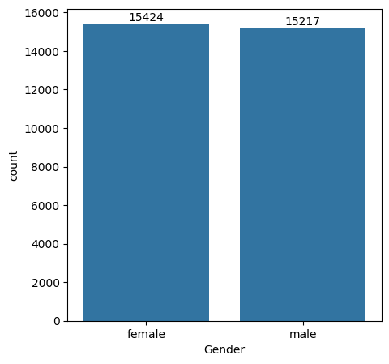

```python
plt.figure(figsize = (5,5))
ax = sns.countplot(data = df, x = "Gender")
ax.bar_label(ax.containers[0])
plt.show
```

### from the above chat we have analysed that the number of number of females in the data is more than the number of males

```python
gb = df.groupby("ParentEduc").agg({"MathScore":'mean',"ReadingScore":'mean', "WritingScore":'mean'})
print(gb)
```

```
                    MathScore  ReadingScore  WritingScore
ParentEduc
associate's degree  68.365586     71.124324     70.299099
bachelor's degree   70.466627     73.062020     73.331069
high school         64.435731     67.213997     65.421136
master's degree     72.336134     75.832921     76.356896
some college        66.390472     69.179708     68.501432
some high school    62.584013     65.510785     63.632409
```

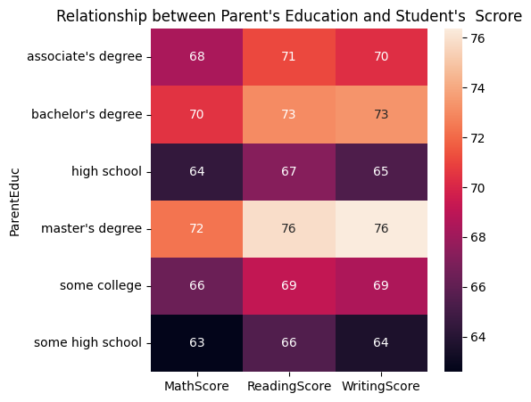

```python
plt.figure(figsize = (5,5))
plt.title("Relationship between Parent's Education and Student's  Scrore")
sns.heatmap(gb, annot=True)
plt.show()
```

### from the above chart we have concluded that the education of the parents have a good impact on the student performance

```python
gb1 = df.groupby("ParentMaritalStatus").agg({"MathScore":'mean',"ReadingScore":'mean', "WritingScore":'mean'})
print(gb1)
```

```
                     MathScore  ReadingScore  WritingScore
ParentMaritalStatus
divorced             66.691197     69.655011     68.799146
married              66.657326     69.389575     68.420981
single               66.165704     69.157250     68.174440
widowed              67.368866     69.651438     68.563452
```

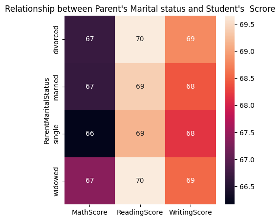

```python
plt.figure(figsize = (5,5))
plt.title("Relationship between Parent's Marital status and Student's  Scrore")
sns.heatmap(gb1, annot=True)
plt.show()
```

### from the above chart we have concluded that the marital status of the parents have negligible impact on the student performance

```python
df.info()
```

```
<class 'pandas.core.frame.DataFrame'>
RangeIndex: 30641 entries, 0 to 30640
Data columns (total 14 columns):
 #   Column               Non-Null Count  Dtype
---  ------               --------------  -----
 0   Gender               30641 non-null  object
 1   EthnicGroup          28801 non-null  object
 2   ParentEduc           28796 non-null  object
 3   LunchType            30641 non-null  object
 4   TestPrep             28811 non-null  object
 5   ParentMaritalStatus  29451 non-null  object
 6   PracticeSport        30010 non-null  object
 7   IsFirstChild         29737 non-null  object
 8   NrSiblings           29069 non-null  float64
 9   TransportMeans       27507 non-null  object
 10  WklyStudyHours       29686 non-null  object
 11  MathScore            30641 non-null  int64
 12  ReadingScore         30641 non-null  int64
 13  WritingScore         30641 non-null  int64
dtypes: float64(1), int64(3), object(10)
memory usage: 3.3+ MB
```

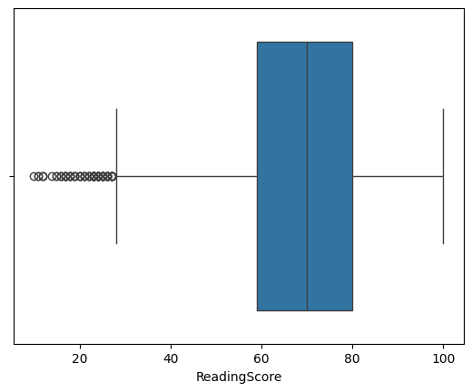

```python
sns.boxplot(data = df, x = "ReadingScore")
plt.show()
```

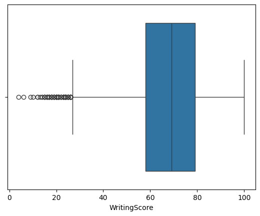

```python
sns.boxplot(data = df, x = "WritingScore")
plt.show()
```

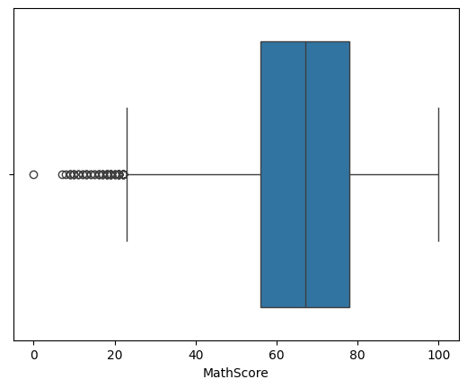

```python
sns.boxplot(data = df, x = "MathScore")
plt.show()
```

## means that maths has the very difficult subject compare to the reading and writhing

```
               MathScore  ReadingScore  WritingScore
PracticeSport
never          64.171079     68.337662     66.522727
regularly      67.839155     69.943019     69.604003
sometimes      66.274831     69.241307     68.072438
```

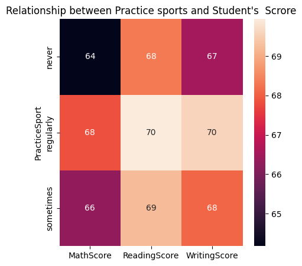

```python
gb2 = df.groupby("PracticeSport").agg({"MathScore":'mean',"ReadingScore":'mean', "WritingScore":'mean'})
print(gb2)
plt.figure(figsize = (5,5))
plt.title("Relationship between Practice sports and Student's  Scrore")
sns.heatmap(gb2, annot=True)
plt.show()
```

### from the above chart we have concluded that the Practicing sports regularly has a slightly impact on the student performance

```
              MathScore  ReadingScore  WritingScore
IsFirstChild
no            66.246832     69.132614     68.210887
yes           66.740646     69.542553     68.558484
```

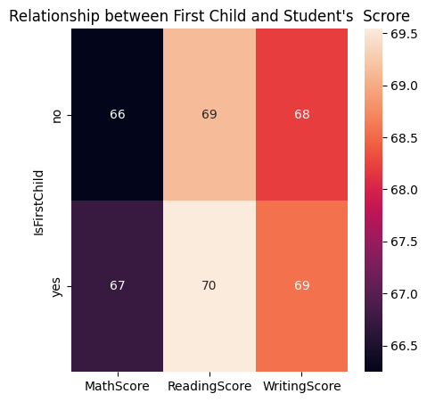

```python
gb3 = df.groupby("IsFirstChild").agg({"MathScore":'mean',"ReadingScore":'mean', "WritingScore":'mean'})
print(gb3)
plt.figure(figsize = (5,5))
plt.title("Relationship between First Child and Student's  Scrore")
sns.heatmap(gb3, annot=True)
plt.show()
```

### from the above chart we have concluded that the being a first child has not significant impact on the student performance

```
            MathScore  ReadingScore  WritingScore
NrSiblings
0.0         66.819449     69.547812     68.746515
1.0         66.473896     69.259097     68.245345
2.0         66.554934     69.472018     68.522533
3.0         66.719092     69.488159     68.650498
4.0         66.245495     69.144169     68.073444
5.0         66.630303     69.453788     68.282576
6.0         65.917219     68.801325     67.860927
7.0         67.615120     69.828179     68.986254
```

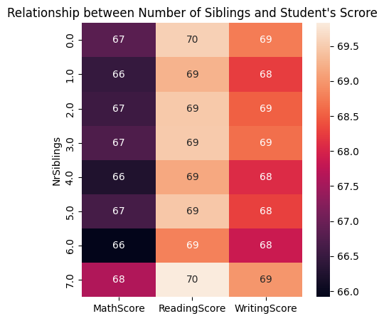

```python
gb4 = df.groupby("NrSiblings").agg({"MathScore":'mean',"ReadingScore":'mean', "WritingScore":'mean'})
print(gb4)
plt.figure(figsize = (5,5))
plt.title("Relationship between Number of Siblings and Student's Scrore")
sns.heatmap(gb4, annot=True)
plt.show()
```

### from the above chart we have concluded that the number of sibling has not significant impact on the student performance

```python
df.info()
```

```
<class 'pandas.core.frame.DataFrame'>
RangeIndex: 30641 entries, 0 to 30640
Data columns (total 14 columns):
 #   Column               Non-Null Count  Dtype
---  ------               --------------  -----
 0   Gender               30641 non-null  object
 1   EthnicGroup          28801 non-null  object
 2   ParentEduc           28796 non-null  object
 3   LunchType            30641 non-null  object
 4   TestPrep             28811 non-null  object
 5   ParentMaritalStatus  29451 non-null  object
 6   PracticeSport        30010 non-null  object
 7   IsFirstChild         29737 non-null  object
 8   NrSiblings           29069 non-null  float64
 9   TransportMeans       27507 non-null  object
 10  WklyStudyHours       29686 non-null  object
 11  MathScore            30641 non-null  int64
 12  ReadingScore         30641 non-null  int64
 13  WritingScore         30641 non-null  int64
dtypes: float64(1), int64(3), object(10)
memory usage: 3.3+ MB
```

```
           MathScore  ReadingScore  WritingScore
TestPrep
completed   69.54666     73.732998     74.703265
none        64.94877     67.051071     65.092756
```

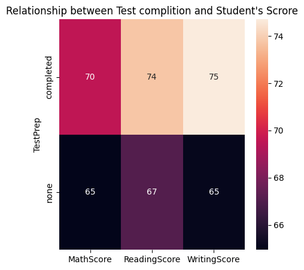

```python
gb5 = df.groupby("TestPrep").agg({"MathScore":'mean',"ReadingScore":'mean', "WritingScore":'mean'})
print(gb5)
plt.figure(figsize = (5,5))
plt.title("Relationship between Test complition and Student's Scrore")
sns.heatmap(gb5, annot=True)
plt.show()
```

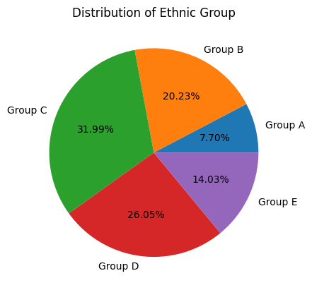

```python
#distribution of Ethnic Groups
groupA = df.loc[(df['EthnicGroup'] == "group A")].count()
groupB = df.loc[(df['EthnicGroup'] == "group B")].count()
groupC = df.loc[(df['EthnicGroup'] == "group C")].count()
groupD = df.loc[(df['EthnicGroup'] == "group D")].count()
groupE = df.loc[(df['EthnicGroup'] == "group E")].count()

l = ["Group A", "Group B", "Group C", "Group D", "Group E"]
mylist = [groupA["EthnicGroup"], groupB["EthnicGroup"], groupC["EthnicGroup"], groupD["EthnicGroup"], groupE["EthnicGroup"]]
plt.pie(mylist, labels = l, autopct = "%1.2f%%")
plt.title("Distribution of Ethnic Group")
plt.show()
```

[output not shown]

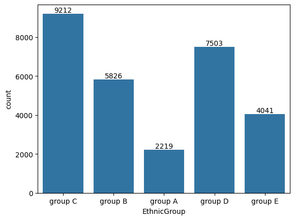

```python
ax = sns.countplot(data = df, x = 'EthnicGroup')
ax.bar_label(ax.containers[0])
```

```
             MathScore  ReadingScore  WritingScore
EthnicGroup
group A      62.991888     66.787742     65.251915
group B      63.490216     67.320460     65.895125
group C      64.695723     68.438233     66.999240
group D      67.666400     70.382247     70.890844
group E      75.298936     74.251423     72.677060
```

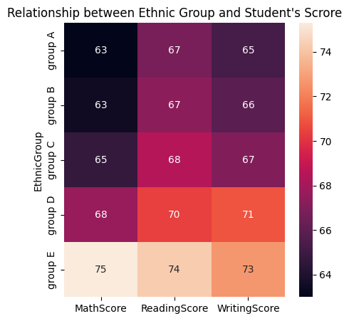

```python
gb6 = df.groupby("EthnicGroup").agg({"MathScore":'mean',"ReadingScore":'mean', "WritingScore":'mean'})
print(gb6)
plt.figure(figsize = (5,5))
plt.title("Relationship between Ethnic Group and Student's Scrore")
sns.heatmap(gb6, annot=True)
plt.show()
```

### from the above chart we have concluded that the Ethnic group a significant impact on the student performance Like ethnic groupE's has the higher performace and groupA has lower performac

```
        MathScore  ReadingScore  WritingScore
Gender
female  64.080654     72.853216     72.856457
male    69.069856     65.854571     63.920418
```

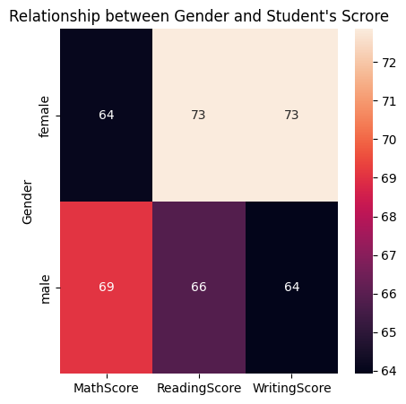

```python
gb7 = df.groupby("Gender").agg({"MathScore":'mean',"ReadingScore":'mean', "WritingScore":'mean'})
print(gb7)
plt.figure(figsize = (5,5))
plt.title("Relationship between Gender and Student's Scrore")
sns.heatmap(gb7, annot=True)
plt.show()
```

### from the above chart we have concluded that the male are good in maths and female are good in reading and writing score

```
                MathScore  ReadingScore  WritingScore
WklyStudyHours
5 - 10          66.870491     69.660532     68.636280
< 5             64.580359     68.176135     67.090192
> 10            68.696655     70.365436     69.777778
```

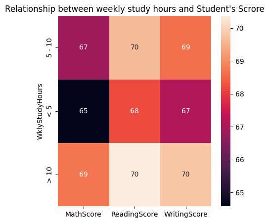

```python
gb8 = df.groupby("WklyStudyHours").agg({"MathScore":'mean',"ReadingScore":'mean', "WritingScore":'mean'})
print(gb8)
plt.figure(figsize = (5,5))
plt.title("Relationship between weekly study hours and Student's Scrore")
sns.heatmap(gb8, annot=True)
plt.show()
```

### from the above chart we have concluded that the students studied less than 5h have lower score and 5 to 10 and more 10 have the higher score in math, reading and writing score

```
                MathScore  ReadingScore  WritingScore
TransportMeans
private         66.511354     69.472364     68.509593
school_bus      66.674636     69.446206     68.492351
```

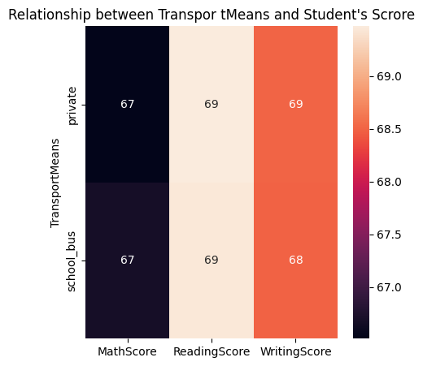

```python
gb9 = df.groupby("TransportMeans").agg({"MathScore":'mean',"ReadingScore":'mean', "WritingScore":'mean'})
print(gb9)
plt.figure(figsize = (5,5))
plt.title("Relationship between Transpor tMeans and Student's Scrore")
sns.heatmap(gb9, annot=True)
plt.show()
```

### from the above chart we have concluded that the students Transport means has no impact on the student score

```
              MathScore  ReadingScore  WritingScore
LunchType
free/reduced  58.862332     64.189735     62.650522
standard      70.709370     72.175634     71.529716
```

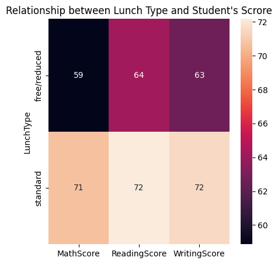

```python
gb10 = df.groupby("LunchType").agg({"MathScore":'mean',"ReadingScore":'mean', "WritingScore":'mean'})
print(gb10)
plt.figure(figsize = (5,5))
plt.title("Relationship between Lunch Type and Student's Scrore")
sns.heatmap(gb10, annot=True)
plt.show()
```

### from the above chart we have concluded that the student's Lunch type plays a significate role in the student's performace because free or reduced lunchtype negativly impacts to the student's score though good or standard meal can contribte to the student's higher performace